# Lesson 180 · Public encoder checkpoint

The runnable work is complete saved-context replay and source/cost auditing. Fresh public-encoder fine-tuning is NOT_RUN and the practical exit is INCOMPLETE. Implement three functions, then explain the gap. Ask the teacher for feedback.

Dependencies: Python3, NumPy, pandas, pyarrow, ml_dtypes. If absent, install these in your chosen notebook environment before running. Default cells perform no network access, GPU work or cloud calls. The source appendix is displayed, not executed.

```python
from pathlib import Path
import json,copy
import numpy as np
import pandas as pd
import ml_dtypes
print("L180: saved evidence only; cloud/API $0; fresh fine-tuning NOT_RUN")
```

```
L180: saved evidence only; cloud/API $0; fresh fine-tuning NOT_RUN
```

**Your win:** explain exactly what evidence would let you claim, “I fine-tuned a public relational encoder on one database.” Complete the three notebook contracts and defend the observed verdict. Read the core path in about 15 minutes; use a separate session for the lab.

**Observed:** complete saved-context replay; public RT-v1 fine-tuning **NOT_RUN**; practical Q2 exit **INCOMPLETE**. The temporal gate fails and one reported full run exceeds the $10 ceiling. No new inference, training or cloud/API spend. Learner defense: **PENDING_WRITTEN_DEFENSE**.

[Student notebook](https://avistian.github.io/relational/labs/0180-public-encoder-checkpoint.ipynb) · [Executed solution](https://avistian.github.io/relational/labs/html/0180-public-encoder-checkpoint.html) · [Solution notebook](https://avistian.github.io/relational/labs/solutions/0180-public-encoder-checkpoint.ipynb) · [Quick reference](https://avistian.github.io/relational/reference/public-encoder-checkpoint.html) · [Reproduction protocol](https://avistian.github.io/relational/labs/l180-reproduction.md).

## 1 · What remains after the previous lessons?

[Lesson 173](https://avistian.github.io/relational/lessons/0173-multi-task-pretraining.html) trained a small course encoder. [Lesson 174](https://avistian.github.io/relational/lessons/0174-fine-tuning-protocol.html) compared adaptation policies on that encoder. Those runs teach parameter updates, but do not demonstrate loading and fine-tuning an externally released relational model. [Lesson 175](https://avistian.github.io/relational/lessons/0175-zero-shot-evaluation.html) attempted public RT-v1 evaluation and stopped at a temporal gate. [Lesson 177](https://avistian.github.io/relational/lessons/0177-compute-budget-realism.html) distinguished full costs from inner timers; [Lesson 178](https://avistian.github.io/relational/lessons/0178-fair-model-comparison.html) showed why a finite forward pass does not prove finite gradients.

The checkpoint joins these ideas: **public initialization → legal task inputs → actual updates → validation selection → independently checked predictions**. A failure anywhere prevents the practical exit. Lesson 179 is not yet present in this checkout; this lesson revisits the relevant failure concepts without assuming it was completed. This advances our mission of making relational-model claims that can survive scrutiny.

## 2 · Name the model before naming the result

Our selected target is **RT-v1 supervised fine-tuning on `rel-f1/driver-dnf`**, using `pretrain_rel-f1_driver-dnf.pt`. The release describes this initialization as pretrained with F1 held out. That is release provenance; reproducing the entire pretraining lineage is a different claim. The later `finetune-from-contd-pretrain` checkpoint already has target supervision and is not a fresh initialization for this experiment. [Pinned release card](https://huggingface.co/stanford-star/rt-v1/blob/299701dedae451f3dfa40717b831d9dc17c0e4e7/README.md)

We pin the repository revision and filename, but **have not downloaded or authenticated the weight bytes**. A public download link does not equal a loaded model. The course encoder from L174 is also not a substitute for these weights.

### Model architecture · what would receive gradients?

A query is a driver and cutoff. The target asks whether a result in **(cutoff, cutoff + 30 days]** has `statusId != 1`; raw-label reconstruction retains the benchmark cohort, which requires future participation. This is not a prospective evaluation of every driver. Mask the query target, sample linked cells, and encode datatype values plus table/column semantics. The frozen MiniLM vectors are inputs; RT's value projections, attention blocks and decoder are trainable. [Original task SQL](https://avistian.github.io/relational/labs/sources/l180/relbench-f1-task.py), [RT §3](https://arxiv.org/html/2510.06377v1#S3).

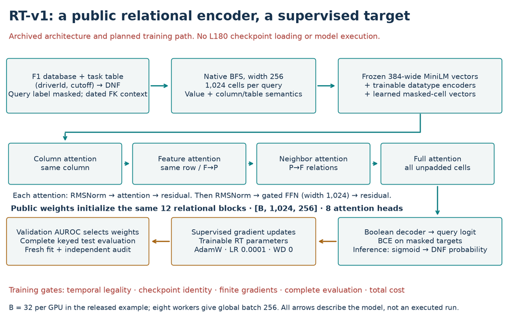

RT-v1 forward and supervised-update paths. Public initialization, datatype encoders, four sequential relation attentions, boolean decoder and validation selection are distinct steps. This is the archived architecture, not an executed L180 model.

**Trace one update:** masked DNF cell → boolean logit → binary cross-entropy → backward gradients through the decoder and relational blocks → AdamW update. The source averages loss over masked cells. The four attention relations run sequentially inside each block; they are not four independent models. A frozen-checkpoint prediction traverses the forward path but does not take this update. The exact [original model](https://avistian.github.io/relational/labs/sources/l180/upstream/rt/model.py) and [trainer](https://avistian.github.io/relational/labs/sources/l180/upstream/rt/main.py) are visible in the notebook appendix.

## 3 · A faithfully replayed failure is useful evidence

The lab authenticates all three saved sampler runs from L175: **2,106 contexts, 2,156,544 cell slots, and all 702 unique `(driverId, cutoff)` keys per seed**. It reconstructs each query label from 26,080 raw results. It does not sample fresh contexts or execute a model.

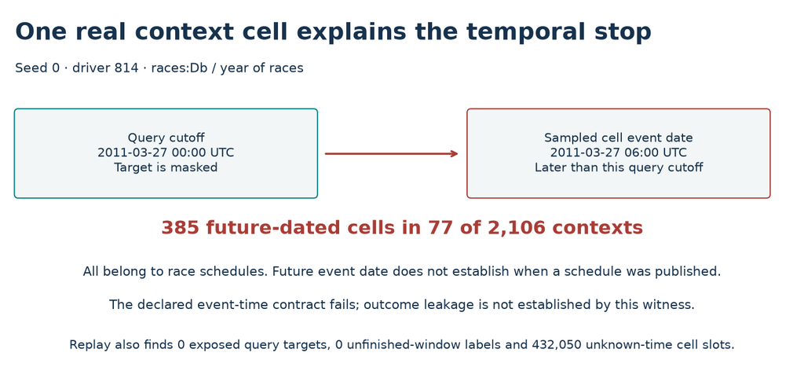

A real saved schedule cell lies after its query cutoff. The event-time rule fails; absent publication histories prevent an outcome-leakage conclusion.

The 385 future-dated cells occur in **77 contexts** and belong to race schedules. A schedule can be published before its event date, but arrival histories are absent here. Therefore the declared event-time rule fails, while **outcome leakage remains unestablished**. The same scan finds zero unmasked query targets and zero labels whose 30-day outcome window is unfinished. Those passes do not cancel the failed rule. The 432,050 unknown-time cell slots also do not prove historical availability.

**Your first live function:** count future-dated cells, exposed targets, unfinished-window labels and unknown timestamps. An unknown timestamp is not silently treated as “safe.” The notebook checks your function against every saved context and rejects a function that always returns zero.

Predict: does reproducing saved context evidence establish fresh public-encoder training? Explain before inspecting the solution.

## 4 · Full reproduction has an exact schedule and a full bill

The paper reports about 33,000 fine-tuning steps, global batch 256, context 1,024, AdamW learning rate `1e-4`, and zero weight decay. The released example spells the step limit as `2**15 + 1 = 32,769` and uses batch 32 **per GPU** on eight GPUs. Record the rounded-paper versus exact-source distinction. [Paper §4.1](https://arxiv.org/html/2510.06377v1#S4.SS1), [Pinned source example](https://avistian.github.io/relational/labs/sources/l180/example_finetune.py).

| Source example behavior | Meaning for this F1 reproduction |
| --- | --- |
| Example task is Amazon churn | F1 task and public initialization must be explicitly configured |
| `save_ckpt_dir=None` | Running unchanged does not retain selected weights |
| Compare higher validation AUROC | Test scores do not choose the checkpoint |
| Evaluate validation and test during training | Must document test visibility; logging alone is not test selection |
| `max_eval_steps=40` | Verify actual per-rank population coverage and complete keys |
| `RT_SAVE_ALL_STEPS` is optional | Preserve enough states and metrics to independently verify selection |

These are source observations, not executed guarantees. F1 training gradients, loaded weights and full train/validation/test coverage remain unchecked. The L178 gradient failure belongs to RelGNN's numerical encoder; it is **not evidence that RT's gradients fail**.

**Worked cost:** eight GPUs × 1.5 hours × 3,600 seconds/hour × $0.000583/GPU-second = **$25.185600**, GPU-only. A100 80 GB gives **$29.980800**. CPU, RAM, setup, evaluation overhead and retries add to this. Both scenarios already exceed the **$10 total lesson cap**. These are calculations from reported runtime and [pinned pricing](https://modal.com/pricing), not measured pilot timings or invoices.

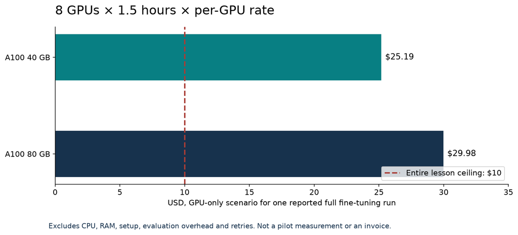

One reported full fine-tuning run already exceeds the entire lesson budget before non-GPU costs. These are price scenarios, not observed runtimes or invoices.

**Your second live function:** compute the complete run's price with decimal arithmetic. Omitting the GPU count yields $3.1482 and admits an unaffordable plan. Replaying old weights or silently cutting the steps would answer a different question. Our authorized work costs **$0 new cloud/API**, with a **1,800-second aggregate local numerical cutoff** including failures and verification.

## 5 · The checkpoint is a conjunction of evidence

**Your third live function:** retain every blocker, then distinguish admission from completed execution and reviewed learner work. Removing only the budget blocker must leave the temporal blocker visible. An affordable GPU subtotal is insufficient: an explicit all-in upper bound must also fit the cap. The actual all-in bound remains unknown. Even when every prerequisite is hypothetically passed, a run that has not happened cannot pass the practical exit.

**Trace admission separately from completion.** In this hypothetical exercise only, suppose all six prerequisites pass and a $5 GPU subtotal sits inside a declared $7 all-in bound and $10 cap. The actual RT experiment above does not satisfy these assumptions:

| Fresh fit | Defense | Practical exit |
| --- | --- | --- |
| Not run | Pending | Incomplete |
| Independently verified | Pending | Pending written defense |
| Independently verified | Pass | Pass |

Admission is ready in all three rows; the evidence of execution and understanding differs. **Transfer check:** discover a failed temporal audit after the final row. The decision becomes BLOCKED and the practical exit INCOMPLETE. A previously reviewed explanation cannot override a failed prerequisite, and a checked box is not a new audit artifact.

Implement checkpoint_decision below; it must retain all blockers.

Use your live checkpoint_decision function in the scenario cells below. Changing assumptions does not change measured evidence.

```
.venv/bin/python labs/_budget_l180.py .venv/bin/python labs/_run_l180.py
# Expected: BLOCKED, exit code 2; fresh fine-tuning NOT_RUN.
```

This executable admission lane and archived trainer are not a validated post-gate training system. A future run needs a separately approved temporal policy, authenticated weights, finite-gradient probe, complete selection/evaluation protocol and all-in cost. No repaired sampler or shorter schedule has been substituted here.

## 6 · Exit: defend the claim you can make

1. Implement the three live notebook functions and run the complete saved-context audit. Explain why correct replay can reproduce a failed scientific gate.
2. Name the initialization, trainable parameters, exact schedule, information-access policy and validation selection rule. Distinguish source inspection from executed verification.
3. State the observed blockers and next required evidence. Defend the schedule-date witness without turning missing availability history into proof of leakage.
4. Keep the **practical exit `INCOMPLETE`** until a public-encoder fit is executed and independently verified. Your explanation remains **`PENDING_WRITTEN_DEFENSE`** until reviewed. Author checks cannot award either.

Write the defense at the end of this notebook and ask the teacher to review it.

**Primary reading:** [RT-v1 §4.1 and Appendix D](https://arxiv.org/html/2510.06377v1#A4), alongside the [pinned training example](https://avistian.github.io/relational/labs/sources/l180/example_finetune.py). Inspect both before proposing a run. Ask the teaching agent about any unclear step, or submit your notebook defense for feedback. Tomorrow, retrieve the distinction between replay, fresh fitting and historical identity without reopening this page.

[Course sequence](https://avistian.github.io/relational/reference/curriculum.html) · [Full measured report](https://avistian.github.io/relational/labs/evidence/l180/report.json) · [Input hashes](https://avistian.github.io/relational/labs/evidence/l180/input-manifest.json) · [Source ledger](https://avistian.github.io/relational/labs/sources/l180/source-ledger-l180.json).

## PROVIDED · Authenticate the complete evidence packet

Every saved context, the raw label oracle, raw result/driver tables, and source example are embedded. SHA256 pins byte identity, not historical legality. The packet needs no download.

[output not shown]

## TODO · Audit all context cells

Return integer counts future_cells, unmasked_query_targets, unavailable_labels, unknown_time_cells. Ignore padding. The unknown timestamp sentinel is -2147483648. A visible label is an unpadded label cell whose mask is false. Its outcome becomes available at timestamp+horizon (equality is allowed). Known future cells violate the event-time rule even if their value is masked; the sampled metadata itself still belongs to that future row. Reject mismatched/non-1D arrays and nonpositive horizons.

```python
def temporal_counts(timestamps,padding,targets,label_cells,masks,cutoff,horizon):
    """Audit source event times; unknown arrival times remain unresolved."""
    import numpy as np
    ts=np.asarray(timestamps,dtype=np.int64)
    pad,target,label,mask=[np.asarray(x,dtype=bool) for x in (padding,targets,label_cells,masks)]
    if ts.ndim!=1 or any(x.shape!=ts.shape for x in (pad,target,label,mask)) or horizon<=0:
        raise ValueError('One-dimensional equal shapes and positive horizon required')
    known=ts!=np.iinfo(np.int32).min
    valid=~pad;visible=valid&label&~mask
    return dict(future_cells=int((valid&known&(ts>cutoff)).sum()),
                unmasked_query_targets=int((valid&target&~mask).sum()),
                unavailable_labels=int((visible&known&(ts+horizon>cutoff)).sum()),
                unknown_time_cells=int((valid&~known).sum()))
```

## TODO · Price the complete protocol

Return a six-decimal USD string using Decimal(str(input)). Multiply GPU count × hours ×3600 × rate × run count, then add overhead once. Require finite positive values, integer GPU/run counts and nonnegative overhead. No rounding through binary floats.

```python
def full_run_cost(gpus,hours,rate_per_second,runs=1,overhead=0):
    """Decimal USD scenario: reported wall time times every allocated GPU."""
    from decimal import Decimal,InvalidOperation
    try:
        values=[Decimal(str(x)) for x in (gpus,hours,rate_per_second,runs,overhead)]
    except (InvalidOperation,ValueError):raise ValueError('Invalid cost input') from None
    g,h,r,n,o=values
    if not all(x.is_finite() for x in values) or min(g,h,r,n)<=0 or o<0 or g!=int(g) or n!=int(n):
        raise ValueError('Finite positive counts, time and rate required')
    return format(g*h*Decimal(3600)*r*n+o,'.6f')
```

## TODO · Keep every blocker and every completion stage

Require PASS for temporal, training_health, checkpoint_bytes, selection, full_population and source_protocol. Missing/non-PASS fields become uppercase blockers. Validate finite nonnegative gpu_only_usd and positive cap_usd; unknown values add BUDGET_UNKNOWN, excess adds BUDGET. Require a finite nonnegative all_in_upper_usd: absent/invalid adds ALL_IN_COST_UNKNOWN, a bound below GPU-only cost adds ALL_IN_COST_INVALID, and a bound above the cap adds BUDGET once. Admission is BLOCKED or READY_FOR_SEPARATELY_AUTHORIZED_RUN. Practical exit starts INCOMPLETE; with no blockers AND fresh_fit VERIFIED it becomes PENDING_WRITTEN_DEFENSE, or PASS if written_defense is PASS. Scenario fields are assumptions, never authorization.

```python
def checkpoint_decision(evidence):
    """Retain all failed prerequisites; hypothetical admission cannot award mastery."""
    from decimal import Decimal,InvalidOperation
    blockers=[]
    for field in ['temporal','training_health','checkpoint_bytes','selection','full_population','source_protocol']:
        if evidence.get(field)!='PASS':blockers.append(field.upper())
    try:
        cost=Decimal(str(evidence.get('gpu_only_usd')));cap=Decimal(str(evidence.get('cap_usd')))
        if not cost.is_finite() or not cap.is_finite() or cost<0 or cap<=0:raise ValueError()
        if cost>cap:blockers.append('BUDGET')
    except (InvalidOperation,ValueError):blockers.append('BUDGET_UNKNOWN')
    try:
        total=Decimal(str(evidence.get('all_in_upper_usd')))
        if not total.is_finite() or total<0:raise ValueError()
        if 'BUDGET_UNKNOWN' not in blockers:
            if total<cost:blockers.append('ALL_IN_COST_INVALID')
            elif total>cap and 'BUDGET' not in blockers:blockers.append('BUDGET')
    except (InvalidOperation,ValueError):blockers.append('ALL_IN_COST_UNKNOWN')
    admission='BLOCKED' if blockers else 'READY_FOR_SEPARATELY_AUTHORIZED_RUN'
    practical='INCOMPLETE'
    if not blockers and evidence.get('fresh_fit')=='VERIFIED':
        practical='PASS' if evidence.get('written_defense')=='PASS' else 'PENDING_WRITTEN_DEFENSE'
    return dict(admission=admission,blockers=blockers,practical_exit=practical)
```

## CHECK · Behavioral contracts

These checks include masked targets, horizon boundaries, eight-GPU accounting, missing evidence, and the distinction between admission and completion.

```python
def checks(count,cost,decide):
    import copy
    import numpy as np
    x=count(np.array([100,110,70,120,-2147483648]),np.array([False,False,False,True,False]),np.array([True,False,False,False,False]),np.array([True,False,True,False,False]),np.array([True,False,False,False,False]),100,30)
    assert x==dict(future_cells=1,unmasked_query_targets=0,unavailable_labels=0,unknown_time_cells=1),x
    assert count([100],[False],[True],[True],[False],100,30)['unmasked_query_targets']==1
    assert count([71],[False],[False],[True],[False],100,30)['unavailable_labels']==1
    assert cost(8,'1.5','0.000583')=='25.185600'
    assert cost(8,'1.5','0.000694',runs=3,overhead='2')=='91.942400'
    for args in [(0,1,1),(8,-1,1),(8,1,'NaN'),(8,1,'Infinity')]:
        try:cost(*args)
        except ValueError:pass
        else:raise AssertionError('invalid cost accepted')
    base=dict(temporal='PASS',training_health='PASS',checkpoint_bytes='PASS',selection='PASS',full_population='PASS',source_protocol='PASS',gpu_only_usd='25.185600',all_in_upper_usd='30',cap_usd='10',fresh_fit='NOT_RUN',written_defense='PENDING_WRITTEN_DEFENSE')
    r=decide(base);assert r['admission']=='BLOCKED' and r['practical_exit']=='INCOMPLETE' and 'BUDGET' in r['blockers']
    bad=copy.deepcopy(base);bad['temporal']='FAIL';r=decide(bad);assert 'TEMPORAL' in r['blockers'] and 'BUDGET' in r['blockers']
    base['gpu_only_usd']='5';base['all_in_upper_usd']='7';r=decide(base);assert r['admission']=='READY_FOR_SEPARATELY_AUTHORIZED_RUN' and r['practical_exit']=='INCOMPLETE'
    base['fresh_fit']='VERIFIED';assert decide(base)['practical_exit']=='PENDING_WRITTEN_DEFENSE'
    base['written_defense']='PASS';assert decide(base)['practical_exit']=='PASS'
    for name in ['temporal','training_health','checkpoint_bytes','selection','full_population','source_protocol']:
        b=copy.deepcopy(base);b[name]='NOT_CHECKED';assert decide(b)['admission']=='BLOCKED',name
        b.pop(name);assert decide(b)['admission']=='BLOCKED',name
    for value in ['NaN','Infinity','-1',None]:
        b=copy.deepcopy(base);b['gpu_only_usd']=value;assert decide(b)['admission']=='BLOCKED'
    b=copy.deepcopy(base);b.pop('all_in_upper_usd');assert 'ALL_IN_COST_UNKNOWN' in decide(b)['blockers']
    b['all_in_upper_usd']='1';assert 'ALL_IN_COST_INVALID' in decide(b)['blockers']
    assert decide({})['practical_exit']=='INCOMPLETE'
    return 'PASS'
```

```python
assert checks(temporal_counts,full_run_cost,checkpoint_decision)=="PASS"
print("CHECK: three live contracts passed")
```

```
CHECK: three live contracts passed
```

## PROVIDED · Full source and context replay

This consumes your three functions, reconstructs all2,106query labels from raw results, checks every complete key and matches every context audit. A zero-count stub cannot produce a valid report.

```python
def audit180(root,manifest,count_fn,cost_fn,decision_fn):
    import ast,hashlib,json
    from pathlib import Path
    import numpy as np
    import pandas as pd
    import ml_dtypes
    root=Path(root)
    for name,digest in manifest['files'].items():
        p=root/name
        if not p.is_file() or hashlib.sha256(p.read_bytes()).hexdigest()!=digest:raise ValueError('Input hash mismatch: '+name)
    cfg=json.loads((root/'config.json').read_text());ref=json.loads((root/'context-audit.json').read_text())
    meta=json.loads((root/'table_info.json').read_text());cols=json.loads((root/'column_index.json').read_text())
    raw=dict(np.load(root/'label-oracle.npz')); results=pd.read_parquet(root/'results.parquet');drivers=pd.read_parquet(root/'drivers.parquet')
    rawcols=dict(driver=results.driverId.to_numpy(),time=(results.date.astype('datetime64[ns]').astype('int64')//10**9).to_numpy(),status=results.statusId.to_numpy(),driver_ids=drivers.driverId.to_numpy())
    for k,v in rawcols.items():
        if not np.array_equal(v,raw[k]):raise ValueError('Raw oracle differs: '+k)
    totals={k:0 for k in ['future_cells','unmasked_query_targets','unavailable_labels','unknown_time_cells']};seeds=[];identities=None
    fields=set(totals);names={v:k for k,v in cols.items()};groups={};witness=None
    for seed in cfg['context_seeds']:
        a=dict(np.load(root/f'contexts-{seed}.npz')); assert a['node_idxs'].shape==(702,1024)
        keys=[];nodes=[];labels=[];future_queries=0;future_cells=0
        for i in range(702):
            q=a['is_targets'][i];assert q.sum()==1
            ts=a['timestamps'][i].astype('int64');pad=a['is_padding'][i];mask=a['masks'][i];node=a['node_idxs'][i];col=a['col_name_idxs'][i]
            cutoff=int(ts[q][0]);qid=int(node[q][0]);driver_row=int(a['f2p_nbr_idxs'][i][q][0,0])-meta['drivers:Db']['node_idx_offset']
            driver=int(raw['driver_ids'][driver_row]);keys.append((driver,cutoff));nodes.append(qid)
            eligible=(raw['driver']==driver)&(raw['time']>cutoff)&(raw['time']<=cutoff+30*86400)
            assert eligible.any()
            y=int((raw['status'][eligible]!=1).any());actual=int(a['boolean_values'][i][q].view(ml_dtypes.bfloat16).astype(float)[0]>0)
            assert y==actual;labels.append(y)
            counts=count_fn(ts,pad,q,col==cols['did_not_finish of driver-dnf'],mask,cutoff,30*86400)
            if set(counts)!=fields:raise ValueError('Incomplete learner audit fields')
            original=ref['records'][seed*702+i]
            assert (original['seed'],original['node_idx'],original['cutoff'])==(seed,qid,cutoff)
            for k,v in counts.items():
                if v!=original[k]:raise ValueError('Context audit differs: '+k)
                totals[k]+=int(v)
            future_queries+=counts['future_cells']>0;future_cells+=counts['future_cells']
            for j in np.flatnonzero((~pad)&(ts>cutoff)):
                table=next(k for k,v in meta.items() if v['node_idx_offset']<=node[j]<v['node_idx_offset']+v['num_nodes'])
                name=table+' / '+names[int(col[j])];groups[name]=groups.get(name,0)+1
                if witness is None:witness=dict(seed=seed,driver_id=driver,query_cutoff=cutoff,context_time=int(ts[j]),table=table,column=names[int(col[j])])
        assert len(set(keys))==702 and sorted(nodes)==list(range(97606,98308))
        keyed=dict(zip(keys,labels))
        if identities is None:identities=keyed
        assert keyed==identities
        seeds.append(dict(seed=seed,queries=702,positive_labels=sum(labels),future_cells=int(future_cells),future_queries=int(future_queries)))
    # Parse, never execute, the original source example.
    tree=ast.parse((root/'example_finetune.py').read_text())
    call=next(n for n in ast.walk(tree) if isinstance(n,ast.Call) and isinstance(n.func,ast.Name) and n.func.id=='main')
    kw={k.arg:k.value for k in call.keywords};values={}
    for k in ['seed','batch_size','seq_len','lr','wd','eval_splits','eval_freq','max_eval_steps','save_ckpt_dir','load_ckpt_path','train_tasks','num_blocks','d_model','num_heads','d_ff']:
        values[k]=ast.literal_eval(kw[k])
    expr=kw['max_steps'];assert isinstance(expr,ast.BinOp) and isinstance(expr.op,ast.Add)
    assert isinstance(expr.left,ast.BinOp) and isinstance(expr.left.op,ast.Pow)
    values['max_steps']=ast.literal_eval(expr.left.left)**ast.literal_eval(expr.left.right)+ast.literal_eval(expr.right)
    assert values['max_steps']==cfg['source_steps'] and values['batch_size']*cfg['world_size']==cfg['global_batch']
    assert values['seq_len']==cfg['seq_len'] and values['lr']==cfg['lr'] and values['wd']==cfg['wd']
    values=json.loads(json.dumps(values))
    trainer=(root/'trainer.py').read_text()
    assert 'if metric > best_metric:' in trainer and 'metrics["val"].items()' in trainer
    costs={hardware:cost_fn(8,cfg['hours_per_run'],rate) for hardware,rate in cfg['rates'].items()}
    evidence=dict(temporal='FAIL_EVENT_TIME',training_health='NOT_CHECKED',checkpoint_bytes='NOT_CHECKED',selection='NOT_CHECKED',full_population='NOT_CHECKED',source_protocol='NOT_CHECKED',gpu_only_usd=costs['A100_40GB'],cap_usd=cfg['cap_usd'],all_in_upper_usd=None,fresh_fit='NOT_RUN',written_defense='PENDING_WRITTEN_DEFENSE')
    decision=decision_fn(evidence)
    return dict(experiment=cfg['name'],audit_status='COMPLETE_SELECTED_SAVED_CONTEXT_REPLAY',contexts=2106,cell_slots=2106*1024,raw_result_rows=len(results),raw_labels_reconstructed=2106,unique_query_keys=702,per_seed=seeds,totals=totals,future_groups=groups,witness=witness,source_example=values,source_findings=dict(global_batch=256,source_steps=values['max_steps'],paper_rounded_steps=33000,example_task='rel-amazon/user-churn',target_task=cfg['task'],validation_comparison='HIGHER_IS_BETTER',checkpoint_saving_default='DISABLED',test_evaluated_during_training=True,full_split_coverage='NOT_CHECKED',trained_checkpoint_bytes='NOT_CHECKED'),costs_gpu_only_usd=costs,evidence=evidence,decision=decision,boundaries=dict(fresh_sampling='NOT_RUN',fresh_finetuning='NOT_RUN',fresh_pretraining='NOT_RUN',fresh_inference='NOT_RUN',whole_paper='NOT_RUN',historical_lineage='NOT_ESTABLISHED',historical_availability='NOT_ESTABLISHED',post_gate_training='UNVALIDATED',cloud_usd=0,learner='PENDING_WRITTEN_DEFENSE',live_colab='NOT_CHECKED',deployment='NOT_CHECKED'))
```

```python
report=audit180(P,manifest,temporal_counts,full_run_cost,checkpoint_decision)
Path('l180-report.json').write_text(json.dumps(report,indent=2))
print(report['audit_status'],report['contexts'],'contexts')
print(json.dumps(report['totals'],indent=2))
print(json.dumps(report['decision'],indent=2))
```

```
COMPLETE_SELECTED_SAVED_CONTEXT_REPLAY 2106 contexts
{
  "future_cells": 385,
  "unmasked_query_targets": 0,
  "unavailable_labels": 0,
  "unknown_time_cells": 432050
}
{
  "admission": "BLOCKED",
  "blockers": [
    "TEMPORAL",
    "TRAINING_HEALTH",
    "CHECKPOINT_BYTES",
    "SELECTION",
    "FULL_POPULATION",
    "SOURCE_PROTOCOL",
    "BUDGET",
    "ALL_IN_COST_UNKNOWN"
  ],
  "practical_exit": "INCOMPLETE"
}
```

## CHECK · Independent scalar oracle

The reference below counts cells one by one instead of using vector masks. It reruns the full packet with an independent temporal implementation, retaining your cost and checkpoint functions.

```python
def scalar(ts,pad,q,lab,mask,cutoff,horizon):
    d=dict(future_cells=0,unmasked_query_targets=0,unavailable_labels=0,unknown_time_cells=0)
    for t,p,target,label,m in zip(ts,pad,q,lab,mask):
        if p:continue
        t=int(t);known=t!=-2147483648
        d['future_cells']+=int(known and t>cutoff)
        d['unmasked_query_targets']+=int(target and not m)
        d['unavailable_labels']+=int(label and not m and known and t+horizon>cutoff)
        d['unknown_time_cells']+=int(not known)
    return d
```

```python
assert audit180(P,manifest,scalar,full_run_cost,checkpoint_decision)==report
assert int(8*5400*583)==int(__import__('decimal').Decimal(report['costs_gpu_only_usd']['A100_40GB'])*1000000)
print('Independent full context and integer micro-dollar checks PASS')
```

```
Independent full context and integer micro-dollar checks PASS
```

## TRY · Remove one blocker, then predict the remaining verdict

This is a hypothetical scenario. It changes neither the report nor your budget authorization.

```python
scenario=copy.deepcopy(report['evidence']);scenario['cap_usd']='40'
a=checkpoint_decision(scenario)
assert 'BUDGET' not in a['blockers'] and 'TEMPORAL' in a['blockers']
print('Budget-only change:',a)
for k in ['temporal','training_health','checkpoint_bytes','selection','full_population','source_protocol']:scenario[k]='PASS'
assert 'ALL_IN_COST_UNKNOWN' in checkpoint_decision(scenario)['blockers']
scenario['all_in_upper_usd']='35' # hypothetical upper bound, not measured or authorized
assert checkpoint_decision(scenario)['practical_exit']=='INCOMPLETE'
print('Prerequisites hypothetically passed; fresh fit is still absent')
assert report['decision']['practical_exit']=='INCOMPLETE'
```

```
Budget-only change: {'admission': 'BLOCKED', 'blockers': ['TEMPORAL', 'TRAINING_HEALTH', 'CHECKPOINT_BYTES', 'SELECTION', 'FULL_POPULATION', 'SOURCE_PROTOCOL', 'ALL_IN_COST_UNKNOWN'], 'practical_exit': 'INCOMPLETE'}
Prerequisites hypothetically passed; fresh fit is still absent
```

## TRY · A flawed price and a corrupted packet

Explain why both must be rejected before using a score. The first mistake counts only one of eight GPUs. The second changes the expected digest for source code.

```python
try:checks(temporal_counts,lambda *a,**kw:'3.148200',checkpoint_decision)
except AssertionError:print('Missing GPU multiplicity rejected')
else:raise AssertionError('Wrong cost admitted')
bad=copy.deepcopy(manifest);bad['files']['example_finetune.py']='0'*64
try:audit180(P,bad,temporal_counts,full_run_cost,checkpoint_decision)
except ValueError:print('Source tampering rejected')
else:raise AssertionError('Corrupt packet admitted')
```

```
Missing GPU multiplicity rejected
Source tampering rejected
```

## EXIT · Your written defense

Fill every field in your own words. Name an observation, its limitation and the next required evidence. No automatic cell changes learner status to PASS. Ask the teacher to review it. Fresh public-encoder training remains a separate outstanding practical requirement.

```python
submission={'learner':'PENDING_WRITTEN_DEFENSE','practical_exit':'INCOMPLETE','public_initialization':'','trainable_path':'','temporal_witness_and_limit':'','full_cost':'','selection_and_coverage':'','next_approved_experiment':''}
Path('l180-submission.json').write_text(json.dumps(submission,indent=2))
```

```
252
```

## Appendix · Original load-bearing implementation

The following pinned code is visible for inspection, not executed by this notebook. The source training example is for Amazon churn, has checkpoint saving disabled and evaluates both splits. A future F1 runner must resolve the documented adaptations and gates. The L180 repository entry point is executable only through admission, and deliberately exits before dispatch. Post-gate training remains UNVALIDATED.

### sources/l180/example_finetune.py

```
from rt.main import main
from rt.tasks import all_tasks, forecast_tasks

if __name__ == "__main__":
    main(
        # misc
        project="rt",
        eval_splits=["val", "test"],
        eval_freq=1_000,
        eval_pow2=False,
        max_eval_steps=40,
        load_ckpt_path="ckpts/rel-amazon_user-churn/rel-amazon_user-churn_best.pt",
        # load_ckpt_path="~/scratch/rt_ckpts/pretrain_rel-amazon_user-churn.pt",
        save_ckpt_dir=None,
        compile_=True,
        seed=0,
        # data
        train_tasks=[("rel-amazon", "user-churn", "churn", [])],
        eval_tasks=[("rel-amazon", "user-churn", "churn", [])],
        batch_size=32,
        num_workers=8,
        max_bfs_width=256,
        # optimization
        lr=1e-4,
        wd=0.0,
        lr_schedule=False,
        max_grad_norm=1.0,
        max_steps=2**15 + 1,
        # model
        embedding_model="all-MiniLM-L12-v2",
        d_text=384,
        seq_len=1024,
        num_blocks=12,
        d_model=256,
        num_heads=8,
        d_ff=1024,
    )
```

### sources/l180/upstream/rt/model.py

```
import json
import os
from functools import partial
from pathlib import Path

import numpy as np
import torch
import torch.nn.functional as F
from einops import rearrange
from einops._torch_specific import allow_ops_in_compiled_graph
from ml_dtypes import bfloat16
from torch import nn
from torch.nn.attention import SDPBackend, sdpa_kernel
from torch.nn.attention.flex_attention import create_block_mask, flex_attention

allow_ops_in_compiled_graph()
flex_attention = torch.compile(flex_attention)


class MaskedAttention(nn.Module):
    def __init__(self, d_model, num_heads):
        super().__init__()
        self.num_heads = num_heads

        self.wq = nn.Linear(d_model, d_model, bias=False)
        self.wk = nn.Linear(d_model, d_model, bias=False)
        self.wv = nn.Linear(d_model, d_model, bias=False)
        self.wo = nn.Linear(d_model, d_model, bias=False)

    def forward(self, x, block_mask):
        q = self.wq(x)
        k = self.wk(x)
        v = self.wv(x)

        q = rearrange(q, "b s (h d) -> b h s d", h=self.num_heads)
        k = rearrange(k, "b s (h d) -> b h s d", h=self.num_heads)
        v = rearrange(v, "b s (h d) -> b h s d", h=self.num_heads)

        if block_mask is None:
            with sdpa_kernel(SDPBackend.FLASH_ATTENTION):
                x = F.scaled_dot_product_attention(q, k, v)
        else:
            x = flex_attention(q, k, v, block_mask=block_mask)

        x = rearrange(x, "b h s d -> b s (h d)")
        x = self.wo(x)
        return x


class FFN(nn.Module):
    def __init__(self, d_model, d_ff):
        super().__init__()

        self.w1 = nn.Linear(d_model, d_ff, bias=False)
        self.w2 = nn.Linear(d_ff, d_model, bias=False)
        self.w3 = nn.Linear(d_model, d_ff, bias=False)

    def forward(self, x):
        return self.w2(F.silu(self.w1(x)) * self.w3(x))


class RelationalBlock(nn.Module):
    def __init__(
        self,
        d_model,
        num_heads,
        d_ff,
    ):
        super().__init__()

        self.norms = nn.ModuleDict(
            {l: nn.RMSNorm(d_model) for l in ["feat", "nbr", "col", "full", "ffn"]}
        )
        self.attns = nn.ModuleDict(
            {
                l: MaskedAttention(d_model, num_heads)
                for l in ["feat", "nbr", "col", "full"]
            }
        )
        self.ffn = FFN(d_model, d_ff)

    def forward(self, x, block_masks):
        for l in ["col", "feat", "nbr", "full"]:
            x = x + self.attns[l](self.norms[l](x), block_mask=block_masks[l])
        x = x + self.ffn(self.norms["ffn"](x))
        return x


def _make_block_mask(mask, batch_size, seq_len, device):
    def _mod(b, h, q_idx, kv_idx):
        return mask[b, q_idx, kv_idx]

    return create_block_mask(
        mask_mod=_mod,
        B=batch_size,
        H=None,
        Q_LEN=seq_len,
        KV_LEN=seq_len,
        device=device,
        _compile=True,
    )


class RelationalTransformer(nn.Module):
    def __init__(
        self,
        num_blocks,
        d_model,
        d_text,
        num_heads,
        d_ff,
    ):
        super().__init__()

        self.enc_dict = nn.ModuleDict(
            {
                "number": nn.Linear(1, d_model, bias=True),
                "text": nn.Linear(d_text, d_model, bias=True),
                "datetime": nn.Linear(1, d_model, bias=True),
                "col_name": nn.Linear(d_text, d_model, bias=True),
                "boolean": nn.Linear(1, d_model, bias=True),
            }
        )
        self.dec_dict = nn.ModuleDict(
            {
                "number": nn.Linear(d_model, 1, bias=True),
                "text": nn.Linear(d_model, d_text, bias=True),
                "datetime": nn.Linear(d_model, 1, bias=True),
                "boolean": nn.Linear(d_model, 1, bias=True),
            }
        )
        self.norm_dict = nn.ModuleDict(
            {
                "number": nn.RMSNorm(d_model),
                "text": nn.RMSNorm(d_model),
                "datetime": nn.RMSNorm(d_model),
                "col_name": nn.RMSNorm(d_model),
                "boolean": nn.RMSNorm(d_model),
            }
        )
        self.mask_embs = nn.ParameterDict(
            {
                t: nn.Parameter(torch.randn(d_model))
                for t in ["number", "text", "datetime", "boolean"]
            }
        )
        self.blocks = nn.ModuleList(
            [RelationalBlock(d_model, num_heads, d_ff) for i in range(num_blocks)]
        )
        self.norm_out = nn.RMSNorm(d_model)
        self.d_model = d_model

    def forward(self, batch):
        node_idxs = batch["node_idxs"]
        f2p_nbr_idxs = batch["f2p_nbr_idxs"]
        col_name_idxs = batch["col_name_idxs"]
        table_name_idxs = batch["table_name_idxs"]
        is_padding = batch["is_padding"]
        batch_size, seq_len = node_idxs.shape

        batch_size, seq_len = node_idxs.shape
        device = node_idxs.device

        # Padding mask for attention pairs (allow only non-pad -> non-pad)
        pad = (~is_padding[:, :, None]) & (~is_padding[:, None, :])  # (B, S, S)

        # cells in the same node
        same_node = node_idxs[:, :, None] == node_idxs[:, None, :]  # (B, S, S)

        # kv index is among q's foreign -> primary neighbors
        kv_in_f2p = (node_idxs[:, None, :, None] == f2p_nbr_idxs[:, :, None, :]).any(
            -1
        )  # (B, S, S)

        # q index is among kv's primary -> foreign neighbors (reverse relation)
        q_in_f2p = (node_idxs[:, :, None, None] == f2p_nbr_idxs[:, None, :, :]).any(
            -1
        )  # (B, S, S)

        # Same column AND same table
        same_col_table = (col_name_idxs[:, :, None] == col_name_idxs[:, None, :]) & (
            table_name_idxs[:, :, None] == table_name_idxs[:, None, :]
        )  # (B, S, S)

        # Final boolean masks (apply padding once here)
        attn_masks = {
            "feat": (same_node | kv_in_f2p) & pad,
            "nbr": q_in_f2p & pad,
            "col": same_col_table & pad,
            "full": pad,
        }

        # Make them contiguous for better kernel performance
        for l in attn_masks:
            attn_masks[l] = attn_masks[l].contiguous()

        # Convert to block masks
        make_block_mask = partial(
            _make_block_mask,
            batch_size=batch_size,
            seq_len=seq_len,
            device=device,
        )
        block_masks = {
            l: make_block_mask(attn_mask) for l, attn_mask in attn_masks.items()
        }

        x = 0
        x = x + (
            self.norm_dict["col_name"](
                self.enc_dict["col_name"](batch["col_name_values"])
            )
            * (~is_padding)[..., None]
        )

        for i, t in enumerate(["number", "text", "datetime", "boolean"]):
            x = x + (
                self.norm_dict[t](self.enc_dict[t](batch[t + "_values"]))
                * ((batch["sem_types"] == i) & ~batch["masks"] & ~is_padding)[..., None]
            )
            x = x + (
                self.mask_embs[t]
                * ((batch["sem_types"] == i) & batch["masks"] & ~is_padding)[..., None]
            )

        for i, block in enumerate(self.blocks):
            x = block(x, block_masks)

        x = self.norm_out(x)

        loss_out = x.new_zeros(())
        yhat_out = {"number": None, "text": None, "datetime": None, "boolean": None}

        B, S, _ = x.shape
        sem_types = batch["sem_types"]  # (B,S) ints 0..3
        masks = batch["masks"].bool()  # (B,S) where to train

        for i, t in enumerate(["number", "text", "datetime", "boolean"]):
            yhat = self.dec_dict[t](x)  # (B,S, D_t)
            y = batch[f"{t}_values"]  # (B,S, D_y)
            sem_type_mask = (sem_types == i) & masks  # (B,S) mask for this type

            if not sem_type_mask.any():
                if t in yhat_out:
                    # still touch the param to avoid unused param error
                    loss_out = loss_out + (yhat.sum() * 0.0)
                    yhat_out[t] = yhat
                continue

            if t in ("number", "datetime"):
                loss_t = F.huber_loss(yhat, y, reduction="none").mean(-1)
            elif t == "boolean":
                loss_t = F.binary_cross_entropy_with_logits(
                    yhat, (y > 0).float(), reduction="none"
                ).mean(-1)
            elif t == "text":
                raise ValueError("masking text not supported")

            # masked sum for this type
            loss_out = loss_out + (loss_t * sem_type_mask).sum()

            if t in yhat_out:
                yhat_out[t] = yhat

        loss_out = loss_out / masks.sum()

        return loss_out, yhat_out
```

### sources/l180/upstream/rt/main.py

```
import os
import random
import time
from pathlib import Path

import numpy as np
import torch
import torch.distributed as dist
import wandb
from sklearn.metrics import r2_score, roc_auc_score
from torch import optim
from torch.nn.parallel import DistributedDataParallel as DDP
from torch.nn.utils import clip_grads_with_norm_, get_total_norm
from torch.utils.data import DataLoader
from tqdm.auto import tqdm

from rt.data import RelationalDataset
from rt.model import RelationalTransformer


def seed_everything(seed=42):
    os.environ["PYTHONHASHSEED"] = str(seed)
    random.seed(seed)
    np.random.seed(seed)
    torch.manual_seed(seed)
    torch.cuda.manual_seed(seed)
    torch.cuda.manual_seed_all(seed)
    # torch.backends.cudnn.deterministic = True
    # torch.backends.cudnn.benchmark = False


def all_gather_nd(tensor: torch.Tensor) -> list[torch.Tensor]:
    """
    Gathers tensor arrays of different lengths in a list.
    The length dimension is 0. This supports any number of extra dimensions in the tensors.
    All the other dimensions should be equal between the tensors.
    Adapted from: https://stackoverflow.com/a/71433508

    Args:
        tensor (Tensor): Tensor to be broadcast from current process.

    Returns:
        list[Tensor]: List of tensors gathered from all processes.
    """
    world_size = dist.get_world_size()
    local_size = torch.tensor(tensor.size(), device=tensor.device)
    all_sizes = [torch.zeros_like(local_size) for _ in range(world_size)]
    dist.all_gather(all_sizes, local_size)

    max_length = max(size[0] for size in all_sizes)

    length_diff = max_length.item() - local_size[0].item()
    if length_diff:
        pad_size = (length_diff, *tensor.size()[1:])
        padding = torch.zeros(pad_size, device=tensor.device, dtype=tensor.dtype)
        tensor = torch.cat((tensor, padding))

    all_tensors_padded = [torch.zeros_like(tensor) for _ in range(world_size)]
    dist.all_gather(all_tensors_padded, tensor)
    all_tensors = []
    for tensor_, size in zip(all_tensors_padded, all_sizes):
        all_tensors.append(tensor_[: size[0]])
    return all_tensors


def main(
    # misc
    project,
    eval_splits,
    eval_freq,
    eval_pow2,
    max_eval_steps,
    load_ckpt_path,
    save_ckpt_dir,
    compile_,
    seed,
    # data
    train_tasks,
    eval_tasks,
    batch_size,
    num_workers,
    max_bfs_width,
    # optimization
    lr,
    wd,
    lr_schedule,
    max_grad_norm,
    max_steps,
    # model
    embedding_model,
    d_text,
    seq_len,
    num_blocks,
    d_model,
    num_heads,
    d_ff,
):
    seed_everything(seed)

    ddp = "LOCAL_RANK" in os.environ
    device = "cuda"
    if ddp:
        os.environ["OMP_NUM_THREADS"] = f"{num_workers}"
        torch.cuda.set_device(int(os.environ["LOCAL_RANK"]))
        dist.init_process_group("nccl")
    if ddp:
        rank = dist.get_rank()
        world_size = dist.get_world_size()
    else:
        rank = 0
        world_size = 1

    if rank == 0:
        run = wandb.init(project=project, config=locals())
        print(run.name)

    torch.multiprocessing.set_sharing_strategy("file_system")
    torch._dynamo.config.cache_size_limit = 16
    torch._dynamo.config.compiled_autograd = compile_ if ddp else False
    torch._dynamo.config.optimize_ddp = True
    torch.set_num_threads(1)

    dataset = RelationalDataset(
        tasks=[
            (db_name, table_name, target_column, "train", columns_to_drop)
            for db_name, table_name, target_column, columns_to_drop in train_tasks
        ],
        batch_size=batch_size,
        seq_len=seq_len,
        rank=rank,
        world_size=world_size,
        max_bfs_width=max_bfs_width,
        embedding_model=embedding_model,
        d_text=d_text,
        seed=seed,
    )
    loader = DataLoader(
        dataset,
        batch_size=None,
        num_workers=num_workers,
        persistent_workers=False,
        pin_memory=True,
        in_order=True,
    )

    eval_loaders = {}
    for db_name, table_name, target_column, columns_to_drop in eval_tasks:
        for split in eval_splits:
            eval_dataset = RelationalDataset(
                tasks=[(db_name, table_name, target_column, split, columns_to_drop)],
                batch_size=batch_size,
                seq_len=seq_len,
                rank=rank,
                world_size=world_size,
                max_bfs_width=max_bfs_width,
                embedding_model=embedding_model,
                d_text=d_text,
                seed=0,
            )
            eval_dataset.sampler.shuffle_py(0)
            eval_loaders[(db_name, table_name, split)] = DataLoader(
                eval_dataset,
                batch_size=None,
                num_workers=num_workers,
                persistent_workers=True,
                pin_memory=True,
                in_order=True,
            )

    net = RelationalTransformer(
        num_blocks=num_blocks,
        d_model=d_model,
        d_text=d_text,
        num_heads=num_heads,
        d_ff=d_ff,
    )
    if load_ckpt_path is not None:
        load_ckpt_path = Path(load_ckpt_path).expanduser()
        state_dict = torch.load(load_ckpt_path, map_location="cpu")
        net.load_state_dict(state_dict)

    if rank == 0:
        param_count = sum(p.numel() for p in net.parameters())
        print(f"{param_count=:_}")

    net = net.to(device)
    net = net.to(torch.bfloat16)
    opt = optim.AdamW(
        net.parameters(),
        lr=lr,
        weight_decay=wd,
        betas=(0.9, 0.999),
        eps=1e-8,
        fused=True,
    )

    if lr_schedule:
        lrs = optim.lr_scheduler.OneCycleLR(
            opt,
            max_lr=lr,
            total_steps=max_steps,
            pct_start=0.2,
            anneal_strategy="linear",
        )

    if ddp:
        net = DDP(net)

    net = torch.compile(net, dynamic=False, disable=not compile_)

    steps = 0
    if rank == 0:
        wandb.log({"epochs": 0}, step=steps)

    eval_loader_iters = {}
    for k, eval_loader in eval_loaders.items():
        eval_loader_iters[k] = iter(eval_loader)
```

```
    def evaluate(net):
        metrics = {"val": {}, "test": {}}
        net.eval()
        with torch.inference_mode():
            for (
                db_name,
                table_name,
                split,
            ), eval_loader_iter in eval_loader_iters.items():
                if table_name in [
                    "item-sales",
                    "user-ltv",
                    "item-ltv",
                    "post-votes",
                    "site-success",
                    "study-adverse",
                    "user-attendance",
                    "driver-position",
                    "ad-ctr",
                ]:
                    task_type = "reg"
                else:
                    task_type = "clf"

                preds = []
                labels = []
                losses = []
                eval_load_times = []
                eval_loader = eval_loaders[(db_name, table_name, split)]
                pbar = tqdm(
                    total=(
                        min(max_eval_steps, len(eval_loader))
                        if max_eval_steps > -1
                        else len(eval_loader)
                    ),
                    desc=f"{db_name}/{table_name}/{split}",
                    disable=rank != 0,
                )

                batch_idx = 0
                while True:
                    tic = time.time()
                    try:
                        batch = next(eval_loader_iter)
                        batch_idx += 1
                    except StopIteration:
                        break
                    toc = time.time()
                    pbar.update(1)

                    eval_load_time = toc - tic
                    if rank == 0:
                        eval_load_times.append(eval_load_time)

                    true_batch_size = batch.pop("true_batch_size")
                    for k in batch:
                        batch[k] = batch[k].to(device, non_blocking=True)

                    batch["masks"][true_batch_size:, :] = False
                    batch["is_targets"][true_batch_size:, :] = False
                    batch["is_padding"][true_batch_size:, :] = True

                    loss, yhat_dict = net(batch)

                    if task_type == "clf":
                        yhat = yhat_dict["boolean"][batch["is_targets"]]
                        y = batch["boolean_values"][batch["is_targets"]].flatten()
                    elif task_type == "reg":
                        yhat = yhat_dict["number"][batch["is_targets"]]
                        y = batch["number_values"][batch["is_targets"]].flatten()

                    assert yhat.size(0) == true_batch_size
                    assert y.size(0) == true_batch_size

                    pred = yhat.flatten()

                    losses.append(loss.item())
                    preds.append(pred)
                    labels.append(y)

                    if max_eval_steps > -1 and batch_idx >= max_eval_steps:
                        break

                eval_loader_iters[(db_name, table_name, split)] = iter(eval_loader)

                pbar.close()
                preds = torch.cat(preds, dim=0)
                labels = torch.cat(labels, dim=0)

                if ddp:
                    # ensure the predictions and labels are gathered jointly
                    preds = all_gather_nd(preds)
                    labels = all_gather_nd(labels)
                else:
                    preds = [preds]
                    labels = [labels]

                if rank == 0:
                    loss = sum(losses) / len(losses)
                    k = f"loss/{db_name}/{table_name}/{split}"
                    avg_eval_load_time = sum(eval_load_times) / len(eval_load_times)
                    wandb.log(
                        {
                            k: loss,
                            f"avg_eval_load_time/{db_name}/{table_name}": avg_eval_load_time,
                        },
                        step=steps,
                    )

                    preds = torch.cat(preds, dim=0).float().cpu().numpy()
                    labels = torch.cat(labels, dim=0).float().cpu().numpy()

                    if task_type == "reg":
                        metric_name = "r2"
                        metric = r2_score(labels, preds)
                    elif task_type == "clf":
                        metric_name = "auc"
                        labels = [int(x > 0) for x in labels]
                        metric = roc_auc_score(labels, preds)

                    k = f"{metric_name}/{db_name}/{table_name}/{split}"
                    wandb.log({k: metric}, step=steps)
                    print(f"\nstep={steps}, \t{k}: {metric}")
                    metrics[split][(db_name, table_name)] = metric

        return metrics

    def checkpoint(best=False, db_name="", table_name=""):
        if rank != 0:
            return
        save_ckpt_dir_ = Path(save_ckpt_dir).expanduser()
        save_ckpt_dir_.mkdir(parents=True, exist_ok=True)
        if best:
            save_ckpt_path = f"{save_ckpt_dir_}/{db_name}_{table_name}_best.pt"
        else:
            save_ckpt_path = f"{save_ckpt_dir_}/{steps=}.pt"

        state_dict = net.module.state_dict() if ddp else net.state_dict()
        torch.save(state_dict, save_ckpt_path)
        print(f"saved checkpoint to {save_ckpt_path}")

    pbar = tqdm(
        total=max_steps,
        desc="steps",
        disable=rank != 0,
    )

    best_val_metrics = dict()
    best_test_metrics = dict()

    while steps < max_steps:
        loader.dataset.sampler.shuffle_py(int(steps / len(loader)))
        loader_iter = iter(loader)
        while steps < max_steps:
            if (eval_freq is not None and steps % eval_freq == 0) or (
                eval_pow2 and steps & (steps - 1) == 0
            ):
                metrics = evaluate(net)
                if save_ckpt_dir is not None:
                    # RT_SAVE_ALL_STEPS=1 -> snapshot every eval step (steps=N.pt) so a caller can
                    # post-hoc select by a metric other than the val-R2/AUC used here (e.g. val-NMAE
                    # for regression). Off by default (preserves original behaviour).
                    if os.environ.get("RT_SAVE_ALL_STEPS") == "1":
                        checkpoint()
                    for (db_name, table_name), metric in metrics["val"].items():
                        # Eval metric is always higher is better (auc, r2)
                        best_metric = best_val_metrics.get(
                            (db_name, table_name), -float("inf")
                        )
                        if metric > best_metric:
                            best_val_metrics[(db_name, table_name)] = metric
                            best_test_metrics[(db_name, table_name)] = metrics["test"][(db_name, table_name)]
                            checkpoint(
                                best=True,
                                db_name=db_name,
                                table_name=table_name
                            )
                        else:
                            checkpoint()
```

```
            net.train()

            tic = time.time()
            try:
                batch = next(loader_iter)
            except StopIteration:
                break
            batch.pop("true_batch_size")
            for k in batch:
                batch[k] = batch[k].to(device, non_blocking=True)
            toc = time.time()
            load_time = toc - tic
            if rank == 0:
                wandb.log({"load_time": load_time}, step=steps)

            loss, _yhat_dict = net(batch)
            opt.zero_grad(set_to_none=True)
            loss.backward()

            grad_norm = get_total_norm(
                [p.grad for p in net.parameters() if p.grad is not None]
            )
            clip_grads_with_norm_(
                net.parameters(), max_norm=max_grad_norm, total_norm=grad_norm
            )

            opt.step()
            if lr_schedule:
                lrs.step()

            steps += 1

            if ddp:
                dist.all_reduce(loss, op=dist.ReduceOp.AVG)
            if rank == 0:
                wandb.log(
                    {
                        "loss": loss,
                        "lr": opt.param_groups[0]["lr"],
                        "epochs": steps / len(loader),
                        "grad_norm": grad_norm,
                    },
                    step=steps,
                )

            pbar.update(1)

    # Print best test metrics
    if rank == 0:
        print("\n" + "="*80)
        print("Best test metrics:")
        print("="*80)
        for (db_name, table_name), metric in best_test_metrics.items():
            print(f"{db_name}/{table_name}/test: {metric:.4f}")
        print("="*80 + "\n")

    if ddp:
        dist.destroy_process_group()


if __name__ == "__main__":
    import strictfire

    strictfire.StrictFire(main)
```

### _run_l180.py

```
"""Executable reproduction admission. No paid or unvalidated post-gate dispatch.

Recompute every prerequisite from pinned evidence. The approved L180 scope
ends here; changing a receipt cannot authorize a larger or repaired experiment.
"""
import json
from pathlib import Path
from _audit_l180 import audit180
from relkit.checkpoint_l180 import temporal_counts,full_run_cost,checkpoint_decision
P=Path(__file__).resolve().parent;E=P/'evidence/l180'
r=audit180(E/'packet',json.loads((E/'input-manifest.json').read_text()),temporal_counts,full_run_cost,checkpoint_decision)
print(json.dumps(dict(reproduction='NOT_RUN',decision=r['decision'],cloud_usd=0,reason='Approved scope is audit/replay only; original trainer is archived in sources/l180/upstream/rt/main.py'),indent=2))
raise SystemExit(2 if r['decision']['admission']=='BLOCKED' else 3)
```